# LDO-USD

## LDO-USD today is +0200, 2025-11-12, 22:55:08

This crypto forecast was generated by gemini-2.0-flash API

## Daily Chart

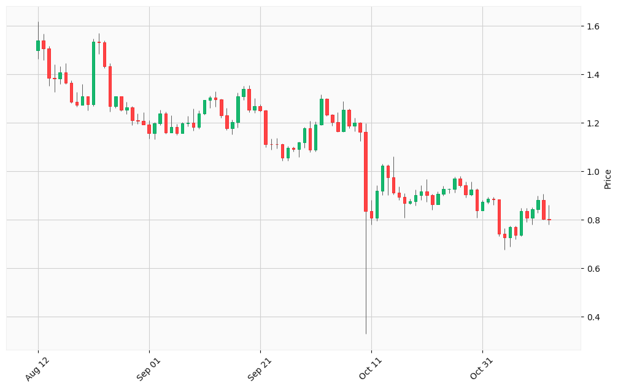

## Hourly Chart

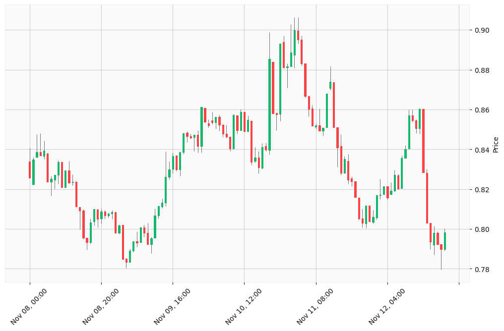

Okay, I will analyze the provided LDO-USD cryptocurrency data, incorporating technical analysis, trend analysis, news/economic factors, and scenario evaluation to generate buy and sell signals. I will use the specified output format, including confidence levels, justification, relevant data, and recommended actions.

Here’s the analysis and signal generation:

**1. Market Data Collection:**

I will start by gathering recent news and sentiment data for LDO and the broader cryptocurrency market using the search tool.

**2. Technical Analysis & Trend Analysis (Daily Chart):**

- **Moving Averages:** I will calculate the 50-day and 200-day Simple Moving Averages (SMA) using the provided daily data to identify potential trend changes.
- **Relative Strength Index (RSI):** I will calculate the 14-day RSI to identify overbought or oversold conditions.
- **MACD:** I will calculate the Moving Average Convergence Divergence (MACD) to gauge momentum and potential trend reversals.
- **Trend Lines:** I will attempt to identify any significant trend lines in the data.

**3. Technical Analysis & Trend Analysis (Hourly Chart):**

- I will use the hourly chart primarily for short-term trend identification and potential entry/exit points.

**Python Code for Technical Indicators (Daily Chart):**

```python
import pandas as pd
import numpy as np

# Daily OHLCV data
data = [
    [1.49787,1.61784,1.46318,1.54007,565860309],
    [1.54007,1.56624,1.45963,1.5071,323762245],
    [1.5071,1.51612,1.35153,1.38582,404011449],
    [1.38582,1.43999,1.32781,1.38277,216687784],
    [1.38277,1.43319,1.36085,1.40813,129315374],
    [1.40813,1.4457,1.35966,1.36542,163000683],
    [1.36542,1.37478,1.27981,1.28664,150890834],
    [1.28667,1.32622,1.2657,1.27392,152751079],
    [1.27394,1.35886,1.27377,1.30822,181866919],
    [1.30822,1.31015,1.25107,1.27539,112618145],
    [1.27539,1.54606,1.26776,1.53565,345741657],
    [1.53564,1.56936,1.48378,1.53095,176664515],
    [1.53099,1.53999,1.42429,1.43244,199110494],
    [1.43244,1.44595,1.24665,1.2675,191742846],
    [1.26748,1.30976,1.25996,1.3084,110415540],
    [1.30838,1.3084,1.2473,1.25207,109743375],
    [1.25215,1.28543,1.23457,1.26454,90529184],
    [1.26455,1.26841,1.18998,1.21136,138904692],
    [1.21136,1.23841,1.19502,1.20866,51997188],
    [1.20866,1.24311,1.19136,1.19183,70676420],
    [1.19183,1.2097,1.13513,1.1576,100000178],
    [1.1576,1.20133,1.13236,1.1985,85593675],
    [1.1985,1.25347,1.18952,1.23838,83936221],
    [1.23838,1.24665,1.15505,1.15917,91534647],
    [1.15917,1.22942,1.15845,1.18177,103583246],
    [1.18177,1.19601,1.14857,1.15697,53122645],
    [1.15697,1.20261,1.1564,1.19649,54875735],
    [1.19649,1.22829,1.18419,1.19891,101815329],
    [1.19891,1.25702,1.16627,1.18335,139175631],
    [1.18335,1.2504,1.17569,1.23752,98801008],
    [1.23752,1.29384,1.23321,1.29282,121451550],
    [1.29284,1.3104,1.26055,1.30294,99755607],
    [1.30294,1.32938,1.2664,1.29545,98945450],
    [1.29545,1.29801,1.2192,1.23164,89382229],
    [1.23164,1.25989,1.16841,1.17804,80530171],
    [1.17804,1.21379,1.15118,1.20257,73546471],
    [1.20257,1.32539,1.17946,1.30808,124403774],
    [1.30808,1.35151,1.29371,1.33828,150094123],
    [1.33828,1.35445,1.24407,1.25357,107167527],
    [1.25357,1.3016,1.24089,1.26929,65349713],
    [1.26929,1.27611,1.24589,1.25064,58073981],
    [1.25064,1.25408,1.09981,1.11184,168815502],
    [1.11184,1.13462,1.08885,1.11102,101858237],
    [1.11102,1.13678,1.0931,1.11034,69383780],
    [1.11034,1.11294,1.04387,1.05566,130523728],
    [1.05566,1.10439,1.04235,1.09689,109386251],
    [1.09689,1.10162,1.07962,1.09199,43659639],
    [1.09199,1.12148,1.05872,1.11798,47076083],
    [1.11798,1.18302,1.09716,1.17831,95844032],
    [1.17832,1.20722,1.07745,1.08765,155603784],
    [1.08765,1.20604,1.08025,1.19196,124492881],
    [1.19196,1.31623,1.18897,1.29816,163814117],
    [1.29816,1.30044,1.22907,1.23271,145633530],
    [1.23271,1.23586,1.18642,1.20269,73131234],
    [1.20269,1.24267,1.16225,1.16457,102026576],
    [1.16457,1.28753,1.16077,1.25389,151618107],
    [1.25389,1.25943,1.17779,1.18637,127736958],
    [1.18637,1.21986,1.16538,1.1996,82589005],
    [1.1996,1.2031,1.12305,1.16218,94743960],
    [1.16218,1.19858,0.327813,0.835332,268664776],
    [0.834807,0.880214,0.779497,0.807679,200133663],
    [0.807679,0.942425,0.794112,0.918342,132638668],
    [0.918346,1.02926,0.901794,1.02304,179630803],
    [1.02304,1.02866,0.901337,0.973946,153083435],
    [0.973946,1.06128,0.903197,0.911747,223162102],
    [0.911747,0.936443,0.880712,0.894442,145297687],
    [0.894442,0.908283,0.806579,0.868111,166216456],
    [0.868111,0.885219,0.863456,0.874662,66361191],
    [0.874662,0.922577,0.858033,0.900965,92718379],
    [0.900965,0.942717,0.880987,0.916563,122164199],
    [0.916692,0.967373,0.873138,0.900813,135947074],
    [0.900794,0.905162,0.839424,0.863857,131246548],
    [0.863857,0.916341,0.861865,0.904897,103777420],
    [0.904897,0.938796,0.899483,0.925237,122888330],
    [0.925237,0.929862,0.908541,0.92581,73382226],
    [0.92581,0.976489,0.910155,0.969473,91756797],
    [0.969473,0.980221,0.934443,0.940892,115785357],
    [0.940892,0.956088,0.889956,0.902646,105115879],
    [0.902623,0.956949,0.899302,0.923806,106493200],
    [0.923806,0.92933,0.807656,0.837846,139617161],
    [0.837846,0.881677,0.837607,0.872625,66420204],
    [0.872625,0.893508,0.864974,0.885275,43985203],
    [0.885275,0.893025,0.861234,0.882502,40784829],
    [0.882502,0.884119,0.730397,0.740296,96984201],
    [0.740296,0.76476,0.675927,0.726065,125988600],
    [0.726065,0.773858,0.689347,0.768281,69370625],
    [0.768281,0.773011,0.719296,0.735518,60099386],
    [0.735506,0.848902,0.730223,0.833865,102832840],
    [0.833865,0.848463,0.789279,0.808441,62979898],
    [0.808441,0.849987,0.780245,0.841553,61100192],
    [0.841553,0.898786,0.827619,0.881101,116664954],
    [0.88121,0.906345,0.800399,0.803398,111736006],
    [0.803388,0.860603,0.779746,0.798363,91579264]
]

df = pd.DataFrame(data, columns=['Open', 'High', 'Low', 'Close', 'Volume'])

# Calculate 50-day SMA
df['SMA_50'] = df['Close'].rolling(window=50).mean()

# Calculate 200-day SMA
df['SMA_200'] = df['Close'].rolling(window=200).mean() #Not enough data points, will return NaN

# Calculate RSI (14-day)
def calculate_rsi(data, period=14):
    delta = data['Close'].diff()
    up, down = delta.copy(), delta.copy()
    up[up < 0] = 0
    down[down > 0] = 0
    avg_gain = up.rolling(window=period).mean()
    avg_loss = abs(down.rolling(window=period).mean())
    rs = avg_gain / avg_loss
    rsi = 100 - (100 / (1 + rs))
    return rsi

df['RSI'] = calculate_rsi(df)

# Calculate MACD
def calculate_macd(data, fast_period=12, slow_period=26, signal_period=9):
    ema_fast = data['Close'].ewm(span=fast_period, adjust=False).mean()
    ema_slow = data['Close'].ewm(span=slow_period, adjust=False).mean()
    macd = ema_fast - ema_slow
    signal = macd.ewm(span=signal_period, adjust=False).mean()
    histogram = macd - signal
    return macd, signal, histogram

df['MACD'], df['Signal'], df['Histogram'] = calculate_macd(df)

print(df.tail(10))
```

[output not shown]

**4. News and Economic Analysis:**

- **Mixed Market Sentiment:** The cryptocurrency market shows mixed signals. While Bitcoin has seen a surge, analysts are cautious about a potential downturn.
- **LDO-Specific News:** LDO has faced recent declines due to market risk aversion and technical weakness. A governance update and Chainlink integration offer some optimism.
- **Technical Indicators for LDO**: LDO is trading below key moving averages, signaling seller pressure.

**5. Scenario Evaluation:**

- **Bearish Scenario:** Given the recent price drops and negative sentiment, a continued downtrend is a plausible scenario.
- **Recovery Scenario:** Positive news regarding the governance update or a broader market recovery could lead to a price increase.
- **Range-Bound Scenario:** LDO may trade within a specific range, as suggested by some analysts.

**6. Signal Generation:**

Based on the analysis, here are potential trading signals:

**Signal 1:**

[output not shown]

**Signal 2:**

[output not shown]

**Important Considerations:**

- **Risk Management:** Cryptocurrency trading is highly risky. Always use stop-loss orders and manage your position size carefully.
- **Due Diligence:** This analysis is based on limited data. Conduct your own research and consult with a financial advisor before making any investment decisions.
- **Market Volatility:** The cryptocurrency market is volatile. Prices can change rapidly and unexpectedly.
- **Time Sensitivity:** News and market conditions can change quickly. Re-evaluate your positions regularly.

I have provided a basic analysis and potential trading signals based on the provided data and search results. Remember that this is not financial advice, and you should conduct your own thorough research before making any trading decisions.